# Chapters 1-7 Summary

Jack Leff

3/4/2016

## Projects 1 & 2

# Code

```
dice <- 1:6
dice <- sample(die, size = 2, replace = TRUE)
sum(dice)
die %*% die
die %o% die

roll <- function() {
  die <- 1:6 1
  dice <- sample(die, size = 2, replace = TRUE)
  sum(dice)
}

rolls <- replicate(10000, roll())
qplot(rolls, binwidth = 1)
```

# Summary

Chapters 1 and 2 dealt with the project of creating a rolling dice function

to do this the book walked through some basic R functions/properties which will be summarized below

Objects: A name that R remembers and can be used to call up an assigned value

```
object <- 2
object()
```

Name limitations: can’t start with a number or special character Functions: A saved series of actions that R can perform

```
insert <- name of function here{
put body of function here
insert arguments as well
close with bracks
}
```

Scripts: can save functions as scripts to maintain and make them more accessible

Packages: The meat of R and the property that makes it such a useful programming langauge. Packages are downloadable sets of functions or properties

How to install Packages

1. Open RStudio.
2. Make sure you are connected to the Internet.
3. Run install.packages(“ggplot2”) at the command line.

Utilize library function to load a package

```
library(rpackage)
library(ggplot2)
```

Installing this package allows for graphing utlizing a fairly complicated function using following code

```
qplot
x <- c(values)
y <- c(values)
qplot(x, y)
```

functions contain help pages that can be accesed by the following `?function`

## Chapters 3-6

# Code

```
die <- c(1, 2, 3, 4, 5, 6)
die
is.vector(die)

text <- c("Hello",  "World")
text

hand <- c("ace", "king", "queen", "jack", "ten")
hand
names(die) <- c("one", "two", "three", "four", "five", "six")
m <- matrix(die, nrow = 2, byrow = TRUE)
m

write.csv(deck, file = "cards.csv", row.names = FALSE)

deal <- function(cards) {
  cards[1, ]
}

shuffle <- function(cards) {
  random <- sample(1:52, size = 52)
  cards[random, ]
}

library(pryr)
parenvs(all = TRUE)
as.environment("package:stats")
globalenv()
baseenv()
emptyenv()
parent.env(globalenv())

show_env <- function(){
  list(ran.in = environment(),
    parent = parent.env(environment()),
    objects = ls.str(environment()))
}

deal <- function() {
  deck[1, ]
```

[output cut: 20 more lines]

```
    assign("deck", deck[-1, ], envir = parent.env(environment()))
    card
  }

  SHUFFLE <- function(){
    random <- sample(1:52, size = 52)
    assign("deck", DECK[random, ], envir = parent.env(environment()))
 }

 list(deal = DEAL, shuffle = SHUFFLE)
}

cards <- setup(deck)
deal <- cards$deal
shuffle <- cards$shuffle
```

# Summary

The project described in chapters 3-6 is attempting to create a function that can shuffle and deal cards.

Atomic Vectors: simple vector of data (die from project 1) Double vector: stores regular numbers `die <- c(1, 2, 3, 4, 5, 6)` integer vector: vectors that can only store numbers without any decimals character vector: stores character information `text <- c("Hello", "World")` logical vectors: store Trues and Falses Names: Can ascribe names to atomic vectors `names(die) <- c("one", "two", "three", "four", "five", "six")` matrix: can turn atomic vectors into matricies using “dim” `dim(die) <- c(2, 3)` * matrix fills columns first then rows * changing dimensions changes “class” of data

To store time `now <- Sys.time()` use sys.time() code factors allow for storing categorical data `gender <- factor(c("male", "female", "female", "male"))`

R coercion * turns logical statements into 1, for yes, and 0, for no.  
* numeric data also becomes character data when coerced

data frames are two dimensional tables while useful they take a lot of time to type in manually…

loading and saving data as a csv file: `write.csv(deck, file = "cards.csv", row.names = FALSE)` use write function to save data as new csv and `attach(cards.csv)` to bring it into environment

R let’s you pull value from data sets by using `deck[ , ]` and typing in indexes between the brackets and seperating them with a comma + positive integers `deck[i,j]` ith row jth column + negative integers, opperate opposite of positive integers + using 0 creates an empty object + blank spaces tell R to get everything from that set `deck[1, ]`

R will match true/false statements to data within the set

by combining `sample` function and setting deck index to `deck[random, ]` you can create a shuffle function!

dollar signs and double brackets as different form of notations + can extract values from sets using $ between data frame and column name + double brackets can be used to return specific elements within a list

But how to change specific values within a data set?

```
vec[1] "selects first value""
vec[1] <- 1000 "changes first value to 1000"
vec[c(1, 3, 5)] <- c(1, 1, 1) "to change multiple values"
```

Can also use $ symbol to alter data sets

```
deck2$new <- 1:52
deck2$new <- NULL
```

logical subsetting: used to specifically extract and modify values within data sets logical subsetting utilizes logical tests (if/then statements and etc)

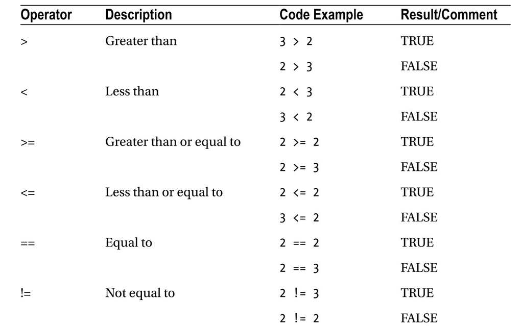

Boolean operators combine multiple logical tests to give more specific answers when searching a data set

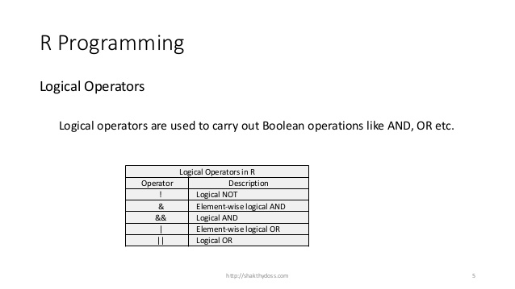

By using boolean operators to track down specific values in data sets (in the book example the queen of hearts was used) you can then replace those specific values or add characters to them

R uses NA to stand in for missing information and * can be removed with `na.rm` function * `is.na` to identify missing values

With the ability to find, alter, and work with data sets under control the book turns to the environement to finish up the blackjack project

the environment is where R stores the data from run lines of code and it stores it in a tree like fashion

basic environment functions * `as.environment("Package:Stats")` * `globalenv()` * `baseenv()` * `emptyenv()` * can look through parent environment with `parent.env(globalenv())` * can access specific values in environment using $ syntax from earlier

Scoping Rules: rules that R uses to look up objects in an environment 1. R looks for objects in the current active environment. 2. When you work at the command line, the active environment is the global environment. Hence, R looks up objects that you call at the command line in the global environment. 3. When R does not find an object in an environment, R looks in the environment’s parent environment, then the parent of the parent, and so on, until R finds the object or reaches the empty environment.

R creates a seperate environment to test a function when it’s used and then if it works brings it to the main environment

using the previously mentioned assign function you can place functions in specific environments

## Chapter 7

# Code

```
get_symbols <- function() {
  wheel <- c("DD", "7", "BBB", "BB", "B", "C", "0")
  sample(wheel, size = 3, replace = TRUE,
    prob = c(0.03, 0.03, 0.06, 0.1, 0.25, 0.01, 0.52))
}

play <- function() {
  symbols <- get_symbols()
  print(symbols) 1
  score(symbols)
}

if (num < 0) {
  print("num is negative.")
  print("Don't worry, I'll fix it.")
  num <- num * -1
  print("Now num is positive.")
}

if ( # Case 1: all the same 1) {
  prize <- # look up the prize 2
} else if ( # Case 2: all bars 3 ) {
  prize <- # assign $5 4
} else {
  # count cherries 5
  prize <- # calculate a prize 6
}

if (same) {
  prize <- # look up the prize
} else if ( # Case 2: all bars ) {
  prize <- # assign $5
} else {
  # count cherries
  prize <- # calculate a prize
}

symbols <- c("B", "B", "B")
all(symbols %in% c("B", "BB", "BBB"))

```

[output cut: 21 more lines]

```
} else if (all(bars)) {
  prize <- 5
} else {
  cherries <- sum(symbols == "C")
  prize <- c(0, 2, 5)[cherries + 1]
}

diamonds <- sum(symbols == "DD")
prize * 2 ^ diamonds

play <- function() {
  symbols <- get_symbols()
  print(symbols)
  score(symbols)
}
```

# Summary

Chapter 7 began the third project of creating a slot machine within R

As seen in the coding section the difficulty is in assigning the different probabilities/values/characters to the seperate functions within the “play” overall function

`get_symbols()` used to assign symbols

To order the function the use of **sequential steps** could be employed

1. get symbols
2. display symbols 3 score symbols

Alternatively these three steps could be done in a **parallel** fashion

Either way, if/else logical statements, from the previous chapters, must be employed to generate the results within the function

look up table: R object that can be used to look up values

since we learned earlier that R coerces true/false into numerical valuse 1/0 we can utilize that with the logical statements to determine payout results

code comments: can use `#toaddtextcommentstocode`